# Quiz Week 1

Manuel Bordes

05/02/2015

## Question 1

> Consider three Web pages with the following links:

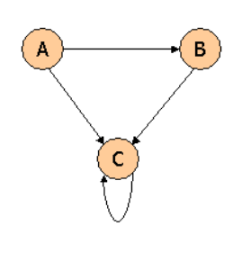

> Suppose we compute PageRank with a β of 0.7, and we introduce the additional constraint that the sum of the PageRanks of the three pages must be 3, to handle the problem that otherwise any multiple of a solution will also be a solution. Compute the PageRanks a, b, and c of the three pages A, B, and C, respectively. Then, identify from the list below, the true statement.

We are going to create the equation of pageRank:

$r = \beta M r +[\frac{(1 - \beta)}{N}]_{N}$ ,

where $[\frac{(1 - \beta)}{N}]_{N}$ is a vector with all $N$ entries $(1-\beta )/{N}$

In each iteration, we need to:

- Compute $r^{new} = \beta M r^{old}$
- Add a contstant value $(1-\beta )/{N}$ to each entry in $r^{new}$

We will call $t$ (teleport link) to the vector $[\frac{(1-\beta)}{N}]_{N}$

So the equation is equal to

$r = \beta M r +t$ ,

Let’s start define the parameters

$\beta=0.7$

```r
beta <- 0.7
```

Number of nodes is equal to 3

$n = 3$

```r
n <- 3
```

The teleport link

```r
# jumping to a random page/teleportation (i.e., 1 - B)
t <- matrix(nrow = n, ncol = 1, rep((1-beta)/n,n))
```

The matrix $M=\left(\begin{array}{lcr}0 & 0 & 0 \\ \frac{1}{2} & 0 & 0\\ \frac{1}{2} & 1 & 1\end{array}\right)$

```r
M <- matrix(c(0, 0.5, 0.5, 0, 0, 1, 0, 0, 1), nrow = 3)
M
```

```
##      [,1] [,2] [,3]
## [1,]  0.0    0    0
## [2,]  0.5    0    0
## [3,]  0.5    1    1
```

```r
# rank vector (i.e., initialize page rank)
r <- matrix(c(1/3, 1/3, 1/3), ncol = 1)
r
```

```
##           [,1]
## [1,] 0.3333333
## [2,] 0.3333333
## [3,] 0.3333333
```

```r
# PageRank: Power Iteration (i.e., iterate until r does not change)
r <- beta * M %*% r + t
r
```

```
##           [,1]
## [1,] 0.1000000
## [2,] 0.2166667
## [3,] 0.6833333
```

```r
r <- beta * M %*% r + t
r
```

```
##       [,1]
## [1,] 0.100
## [2,] 0.135
## [3,] 0.765
```

```r
r <- beta * M %*% r + t
r
```

```
##       [,1]
## [1,] 0.100
## [2,] 0.135
## [3,] 0.765
```

```r
r <- beta * M %*% r + t
r
```

```
##       [,1]
## [1,] 0.100
## [2,] 0.135
## [3,] 0.765
```

r hasn’t changed in the last iteration

- a + b = 0.655 FALSE

```r
# a + b
(r[1] + r[2]) * 3
```

```
## [1] 0.705
```

- a + c = 2.035 FALSE

```r
# a + c
(r[1] + r[3]) * 3
```

```
## [1] 2.595
```

- a + c = 2.595 TRUE

```r
# a + C
(r[1] + r[3]) * 3
```

```
## [1] 2.595
```

- b + c = 2.5 FALSE

```r
# b + c
(r[2] + r[3]) * 3
```

```
## [1] 2.7
```

## Question 2

> Consider three Web pages with the following links:

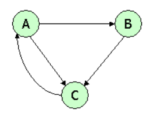

Let’s start define the parameters

$\beta=0.85$

```r
beta <- 0.85
```

Number of nodes is equal to 3

$n = 3$

```r
n <- 3
```

The teleport link

```r
# jumping to a random page/teleportation (i.e., 1 - B)
t <- matrix(nrow = n, ncol = 1, rep((1-beta)/n,n))
```

The matrix $M=\left(\begin{array}{lcr}0 & 0 & 1 \\ \frac{1}{2} & 0 & 0\\ \frac{1}{2} & 1 & 0\end{array}\right)$

```r
M <- matrix(c(0, 0.5, 0.5, 0, 0, 1, 1, 0, 0), nrow = 3)
M
```

```
##      [,1] [,2] [,3]
## [1,]  0.0    0    1
## [2,]  0.5    0    0
## [3,]  0.5    1    0
```

```r
# rank vector (i.e., initialize page rank)
r <- matrix(c(1/3, 1/3, 1/3), ncol = 1)
r
```

```
##           [,1]
## [1,] 0.3333333
## [2,] 0.3333333
## [3,] 0.3333333
```

```r
# PageRank: Power Iteration (i.e., iterate until r does not change)

for (i in 1:30) {
    r <- beta * M %*% r + t
}
r
```

```
##           [,1]
## [1,] 0.3877897
## [2,] 0.2148106
## [3,] 0.3973997
```

```r
r <- beta * M %*% r + t
r
```

```
##           [,1]
## [1,] 0.3877897
## [2,] 0.2148106
## [3,] 0.3973997
```

Afer 30 iterations converge

```r
# rank vector (i.e., initialize page rank)
if(round(r[1],5) == round((r[2]+0.15),5)) {
    print('a = c + .15b')
}else{
    print('a != c + .15b')
}
```

```
## [1] "a != c + .15b"
```

```r
if(round(r[1],5)==round(0.9*r[3] + 0.05 * r[2],5)) {
    print('a = .9c + .05b')
}else{
    print('a != .9c + .05b')
}
```

```
## [1] "a != .9c + .05b"
```

```r
if(round(0.95*r[2],5)== round(0.475 * r[1] + 0.05* r[3],5)) {
    print('.95b = .475a + .05c')
}else{
    print('.95b != .475a + .05c')
}
```

```
## [1] ".95b = .475a + .05c"
```

```r
if(round(0.85*r[1],5) == round( r[3]+0.15* r[2],5)) {
    print('.85a = c + .15b')
}else{
    print('.85a != c + .15b')
}
```

```
## [1] ".85a != c + .15b"
```

## Question 3

> Consider three Web pages with the following links:

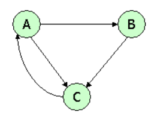

> Assuming no “taxation,” compute the PageRanks a, b, and c of the three pages A, B, and C, using iteration, starting with the “0th” iteration where all three pages have rank a = b = c = 1.

> Compute as far as the 5th iteration, and also determine what the PageRanks are in the limit. Then, identify the true statement from the list below.
> - After iteration 5, a = 21/16
> - After iteration 5, b = 5/8
> - After iteration 5, b = 1/2
> - After iteration 5, b = 9/16

Let’s start define the parameters

The matrix $M=\left(\begin{array}{lcr}0 & 0 & 1 \\ \frac{1}{2} & 0 & 0\\ \frac{1}{2} & 1 & 0\end{array}\right)$

```r
M <- matrix(c(0, 0.5, 0.5, 0, 0, 1, 1, 0, 0), nrow = 3)
M
```

```
##      [,1] [,2] [,3]
## [1,]  0.0    0    1
## [2,]  0.5    0    0
## [3,]  0.5    1    0
```

```r
# rank vector (i.e., initialize page rank)
r <- matrix(c(1, 1, 1), ncol = 1)
```

```r
# rank vector (i.e., initialize page rank)
r <- M %*% r
r
```

```
##      [,1]
## [1,]  1.0
## [2,]  0.5
## [3,]  1.5
```

```r
for (i in 1:5) {
    r <-  M %*% r
}
r
```

```
##       [,1]
## [1,] 1.125
## [2,] 0.625
## [3,] 1.250
```

```r
option_1_a<-21/16
option_2_b<-5/8
option_3_b<-1/2
option_4_b<-9/16

option_1_a
```

```
## [1] 1.3125
```

```r
option_2_b
```

```
## [1] 0.625
```

```r
option_3_b
```

```
## [1] 0.5
```

```r
option_4_b
```

```
## [1] 0.5625
```